# Employee Attrition

[figure not shown]

This project aims to highlight some features that cause Employee attrition by using the dataset that published by IBM : https://developer.ibm.com/patterns/data-science-life-cycle-in-action-to-solve-employee-attrition-problem/#descrip

# 1. Import required packages

```python
import numpy as np
import pandas as pd
import matplotlib.pyplot as plt
%matplotlib inline
import seaborn as sns
import warnings
warnings.filterwarnings('ignore')
import cufflinks as cf
from plotly.offline import download_plotlyjs,init_notebook_mode,plot,iplot
init_notebook_mode(connected=True)

import plotly.graph_objects as go
import plotly.figure_factory as ff
```

# 2. Data Extracting

### 2.1 Exploring the data set

load the dataset and have clear understanding of the dataset attributes

```python
#reading CSV file
df = pd.read_csv('emp_attrition.csv')
```

```python
#getting the first rows
df.head(10)
```

|  | Age | Attrition | BusinessTravel | DailyRate | Department | DistanceFromHome | Education | EducationField | EmployeeCount | EmployeeNumber | ... | RelationshipSatisfaction | StandardHours | StockOptionLevel | TotalWorkingYears | TrainingTimesLastYear | WorkLifeBalance | YearsAtCompany | YearsInCurrentRole | YearsSinceLastPromotion | YearsWithCurrManager |
| --- | --- | --- | --- | --- | --- | --- | --- | --- | --- | --- | --- | --- | --- | --- | --- | --- | --- | --- | --- | --- | --- |
| 0 | 41 | Yes | Travel_Rarely | 1102 | Sales | 1 | 2 | Life Sciences | 1 | 1 | ... | 1 | 80 | 0 | 8 | 0 | 1 | 6 | 4 | 0 | 5 |
| 1 | 49 | No | Travel_Frequently | 279 | Research & Development | 8 | 1 | Life Sciences | 1 | 2 | ... | 4 | 80 | 1 | 10 | 3 | 3 | 10 | 7 | 1 | 7 |
| 2 | 37 | Yes | Travel_Rarely | 1373 | Research & Development | 2 | 2 | Other | 1 | 4 | ... | 2 | 80 | 0 | 7 | 3 | 3 | 0 | 0 | 0 | 0 |
| 3 | 33 | No | Travel_Frequently | 1392 | Research & Development | 3 | 4 | Life Sciences | 1 | 5 | ... | 3 | 80 | 0 | 8 | 3 | 3 | 8 | 7 | 3 | 0 |
| 4 | 27 | No | Travel_Rarely | 591 | Research & Development | 2 | 1 | Medical | 1 | 7 | ... | 4 | 80 | 1 | 6 | 3 | 3 | 2 | 2 | 2 | 2 |
| 5 | 32 | No | Travel_Frequently | 1005 | Research & Development | 2 | 2 | Life Sciences | 1 | 8 | ... | 3 | 80 | 0 | 8 | 2 | 2 | 7 | 7 | 3 | 6 |
| 6 | 59 | No | Travel_Rarely | 1324 | Research & Development | 3 | 3 | Medical | 1 | 10 | ... | 1 | 80 | 3 | 12 | 3 | 2 | 1 | 0 | 0 | 0 |
| 7 | 30 | No | Travel_Rarely | 1358 | Research & Development | 24 | 1 | Life Sciences | 1 | 11 | ... | 2 | 80 | 1 | 1 | 2 | 3 | 1 | 0 | 0 | 0 |
| 8 | 38 | No | Travel_Frequently | 216 | Research & Development | 23 | 3 | Life Sciences | 1 | 12 | ... | 2 | 80 | 0 | 10 | 2 | 3 | 9 | 7 | 1 | 8 |
| 9 | 36 | No | Travel_Rarely | 1299 | Research & Development | 27 | 3 | Medical | 1 | 13 | ... | 2 | 80 | 2 | 17 | 3 | 2 | 7 | 7 | 7 | 7 |

10 rows × 35 columns

```python
#explore the shape of the dataset
print('Rows x Columns : ', df.shape[0], 'x', df.shape[1])
```

```
Rows x Columns :  1470 x 35
```

```python
#read all coulmns names
print('Features: \n', df.columns.tolist())
```

```
Features:
 ['Age', 'Attrition', 'BusinessTravel', 'DailyRate', 'Department', 'DistanceFromHome', 'Education', 'EducationField', 'EmployeeCount', 'EmployeeNumber', 'EnvironmentSatisfaction', 'Gender', 'HourlyRate', 'JobInvolvement', 'JobLevel', 'JobRole', 'JobSatisfaction', 'MaritalStatus', 'MonthlyIncome', 'M…
```

```python
#getting the unique values
print('\nUnique values:')
print(df.nunique())
for col in df.columns:
    print(col, ':', sorted(df[col].unique()))
```

```
Unique values:
Age                           43
Attrition                      2
BusinessTravel                 3
DailyRate                    886
Department                     3
DistanceFromHome              29
Education                      5
EducationField                 6
EmployeeCount                  1
EmployeeNumber              1470
EnvironmentSatisfaction        4
Gender                         2
HourlyRate                    71
JobInvolvement                 4
JobLevel                       5
JobRole                        9
JobSatisfaction                4
MaritalStatus                  3
MonthlyIncome               1349
MonthlyRate                 1427
NumCompaniesWorked            10
Over18                         1
OverTime                       2
PercentSalaryHike             15
PerformanceRating              2
RelationshipSatisfaction       4
StandardHours                  1
StockOptionLevel               4
TotalWorkingYears             40
TrainingTimesLastYear          7
WorkLifeBalance                4
YearsAtCompany                37
YearsInCurrentRole            19
YearsSinceLastPromotion       16
YearsWithCurrManager          18
dtype: int64
Age : [18, 19, 20, 21, 22, 23, 24, 25, 26, 27, 28, 29, 30, 31, 32, 33, 34, 35, 36, 37, 38, 39, 40, 41, 42, 43, 44, 45, 46, 47, 48, 49, 50, 51, 52, 53, 54, 55, 56, 57, 58, 59, 60]
Attrition : ['No', 'Yes']
BusinessTravel : ['Non-Travel', 'Travel_Frequently', 'Travel_Rarely']
```

[output cut: 17 more lines]

```
NumCompaniesWorked : [0, 1, 2, 3, 4, 5, 6, 7, 8, 9]
Over18 : ['Y']
OverTime : ['No', 'Yes']
PercentSalaryHike : [11, 12, 13, 14, 15, 16, 17, 18, 19, 20, 21, 22, 23, 24, 25]
PerformanceRating : [3, 4]
RelationshipSatisfaction : [1, 2, 3, 4]
StandardHours : [80]
StockOptionLevel : [0, 1, 2, 3]
TotalWorkingYears : [0, 1, 2, 3, 4, 5, 6, 7, 8, 9, 10, 11, 12, 13, 14, 15, 16, 17, 18, 19, 20, 21, 22, 23, 24, 25, 26, 27, 28, 29, 30, 31, 32, 33, 34, 35, 36, 37, 38, 40]
TrainingTimesLastYear : [0, 1, 2, 3, 4, 5, 6]
WorkLifeBalance : [1, 2, 3, 4]
YearsAtCompany : [0, 1, 2, 3, 4, 5, 6, 7, 8, 9, 10, 11, 12, 13, 14, 15, 16, 17, 18, 19, 20, 21, 22, 23, 24, 25, 26, 27, 29, 30, 31, 32, 33, 34, 36, 37, 40]
YearsInCurrentRole : [0, 1, 2, 3, 4, 5, 6, 7, 8, 9, 10, 11, 12, 13, 14, 15, 16, 17, 18]
YearsSinceLastPromotion : [0, 1, 2, 3, 4, 5, 6, 7, 8, 9, 10, 11, 12, 13, 14, 15]
YearsWithCurrManager : [0, 1, 2, 3, 4, 5, 6, 7, 8, 9, 10, 11, 12, 13, 14, 15, 16, 17]
```

#### * As we can see “Over18”, “Standard Hours” and “Employee Count” contain the same value for each observation, which we do not need them in visualizing the dataset

-find missing data, remove data that will not assist with the visualization in analysis processing

```python
df.isnull().sum()
```

```
Age                         0
Attrition                   0
BusinessTravel              0
DailyRate                   0
Department                  0
DistanceFromHome            0
Education                   0
EducationField              0
EmployeeCount               0
EmployeeNumber              0
EnvironmentSatisfaction     0
Gender                      0
HourlyRate                  0
JobInvolvement              0
JobLevel                    0
JobRole                     0
JobSatisfaction             0
MaritalStatus               0
MonthlyIncome               0
MonthlyRate                 0
NumCompaniesWorked          0
Over18                      0
OverTime                    0
PercentSalaryHike           0
PerformanceRating           0
RelationshipSatisfaction    0
StandardHours               0
StockOptionLevel            0
TotalWorkingYears           0
TrainingTimesLastYear       0
WorkLifeBalance             0
YearsAtCompany              0
YearsInCurrentRole          0
YearsSinceLastPromotion     0
YearsWithCurrManager        0
dtype: int64
```

```python
df.count()
```

```
Age                         1470
Attrition                   1470
BusinessTravel              1470
DailyRate                   1470
Department                  1470
DistanceFromHome            1470
Education                   1470
EducationField              1470
EmployeeCount               1470
EmployeeNumber              1470
EnvironmentSatisfaction     1470
Gender                      1470
HourlyRate                  1470
JobInvolvement              1470
JobLevel                    1470
JobRole                     1470
JobSatisfaction             1470
MaritalStatus               1470
MonthlyIncome               1470
MonthlyRate                 1470
NumCompaniesWorked          1470
Over18                      1470
OverTime                    1470
PercentSalaryHike           1470
PerformanceRating           1470
RelationshipSatisfaction    1470
StandardHours               1470
StockOptionLevel            1470
TotalWorkingYears           1470
TrainingTimesLastYear       1470
WorkLifeBalance             1470
YearsAtCompany              1470
YearsInCurrentRole          1470
YearsSinceLastPromotion     1470
YearsWithCurrManager        1470
dtype: int64
```

```python
df.isnull().sum().any()
```

```
False
```

#### * This result shows if we have any missing values we used different codes. And as we can see, there are no missing values. Otherwise, we would have done some techniques, like dropping columns or rows, doing a replacement of mising values by the mean, backward, or frontward values.

```python
#drop unwanted columns

df = df.drop(['Over18','StandardHours','EmployeeCount'], axis=1)
```

```python
df.info()
```

```
<class 'pandas.core.frame.DataFrame'>
RangeIndex: 1470 entries, 0 to 1469
Data columns (total 32 columns):
Age                         1470 non-null int64
Attrition                   1470 non-null object
BusinessTravel              1470 non-null object
DailyRate                   1470 non-null int64
Department                  1470 non-null object
DistanceFromHome            1470 non-null int64
Education                   1470 non-null int64
EducationField              1470 non-null object
EmployeeNumber              1470 non-null int64
EnvironmentSatisfaction     1470 non-null int64
Gender                      1470 non-null object
HourlyRate                  1470 non-null int64
JobInvolvement              1470 non-null int64
JobLevel                    1470 non-null int64
JobRole                     1470 non-null object
JobSatisfaction             1470 non-null int64
MaritalStatus               1470 non-null object
MonthlyIncome               1470 non-null int64
MonthlyRate                 1470 non-null int64
NumCompaniesWorked          1470 non-null int64
OverTime                    1470 non-null object
PercentSalaryHike           1470 non-null int64
PerformanceRating           1470 non-null int64
RelationshipSatisfaction    1470 non-null int64
StockOptionLevel            1470 non-null int64
TotalWorkingYears           1470 non-null int64
TrainingTimesLastYear       1470 non-null int64
WorkLifeBalance             1470 non-null int64
YearsAtCompany              1470 non-null int64
YearsInCurrentRole          1470 non-null int64
YearsSinceLastPromotion     1470 non-null int64
YearsWithCurrManager        1470 non-null int64
dtypes: int64(24), object(8)
memory usage: 367.6+ KB
```

#### * Since “Over18”, “Standard Hours” and “Employee Count” has a static varible, we remove them to improve the speed of processing the dataframe.

### 2.2 Descriptive statstic

```python
df.describe()
```

|  | Age | DailyRate | DistanceFromHome | Education | EmployeeNumber | EnvironmentSatisfaction | HourlyRate | JobInvolvement | JobLevel | JobSatisfaction | ... | PerformanceRating | RelationshipSatisfaction | StockOptionLevel | TotalWorkingYears | TrainingTimesLastYear | WorkLifeBalance | YearsAtCompany | YearsInCurrentRole | YearsSinceLastPromotion | YearsWithCurrManager |
| --- | --- | --- | --- | --- | --- | --- | --- | --- | --- | --- | --- | --- | --- | --- | --- | --- | --- | --- | --- | --- | --- |
| count | 1470.000000 | 1470.000000 | 1470.000000 | 1470.000000 | 1470.000000 | 1470.000000 | 1470.000000 | 1470.000000 | 1470.000000 | 1470.000000 | ... | 1470.000000 | 1470.000000 | 1470.000000 | 1470.000000 | 1470.000000 | 1470.000000 | 1470.000000 | 1470.000000 | 1470.000000 | 1470.000000 |
| mean | 36.923810 | 802.485714 | 9.192517 | 2.912925 | 1024.865306 | 2.721769 | 65.891156 | 2.729932 | 2.063946 | 2.728571 | ... | 3.153741 | 2.712245 | 0.793878 | 11.279592 | 2.799320 | 2.761224 | 7.008163 | 4.229252 | 2.187755 | 4.123129 |
| std | 9.135373 | 403.509100 | 8.106864 | 1.024165 | 602.024335 | 1.093082 | 20.329428 | 0.711561 | 1.106940 | 1.102846 | ... | 0.360824 | 1.081209 | 0.852077 | 7.780782 | 1.289271 | 0.706476 | 6.126525 | 3.623137 | 3.222430 | 3.568136 |
| min | 18.000000 | 102.000000 | 1.000000 | 1.000000 | 1.000000 | 1.000000 | 30.000000 | 1.000000 | 1.000000 | 1.000000 | ... | 3.000000 | 1.000000 | 0.000000 | 0.000000 | 0.000000 | 1.000000 | 0.000000 | 0.000000 | 0.000000 | 0.000000 |
| 25% | 30.000000 | 465.000000 | 2.000000 | 2.000000 | 491.250000 | 2.000000 | 48.000000 | 2.000000 | 1.000000 | 2.000000 | ... | 3.000000 | 2.000000 | 0.000000 | 6.000000 | 2.000000 | 2.000000 | 3.000000 | 2.000000 | 0.000000 | 2.000000 |
| 50% | 36.000000 | 802.000000 | 7.000000 | 3.000000 | 1020.500000 | 3.000000 | 66.000000 | 3.000000 | 2.000000 | 3.000000 | ... | 3.000000 | 3.000000 | 1.000000 | 10.000000 | 3.000000 | 3.000000 | 5.000000 | 3.000000 | 1.000000 | 3.000000 |
| 75% | 43.000000 | 1157.000000 | 14.000000 | 4.000000 | 1555.750000 | 4.000000 | 83.750000 | 3.000000 | 3.000000 | 4.000000 | ... | 3.000000 | 4.000000 | 1.000000 | 15.000000 | 3.000000 | 3.000000 | 9.000000 | 7.000000 | 3.000000 | 7.000000 |
| max | 60.000000 | 1499.000000 | 29.000000 | 5.000000 | 2068.000000 | 4.000000 | 100.000000 | 4.000000 | 5.000000 | 4.000000 | ... | 4.000000 | 4.000000 | 3.000000 | 40.000000 | 6.000000 | 4.000000 | 40.000000 | 18.000000 | 15.000000 | 17.000000 |

8 rows × 24 columns

#### Visualizing these statistics using boxplots

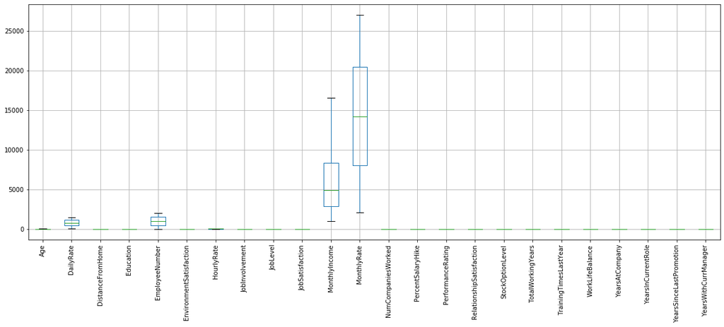

```python
plt.rcParams["figure.figsize"] = (20,7)
df.boxplot(sym="")
plt.xticks(rotation=90)
```

#### * It can be observed that the value ranges of columns (MonthlyIncome, MonthlyRate, EmployeeNumber, DailyRate) are significantly higher than the remaining numeric columns. This can be corrected using normalization.

### Normalizing the dataset

```python
from sklearn.preprocessing import StandardScaler

standard=df.copy()
val=standard.select_dtypes("int64")

col_names=list(val.columns)

features =  val[col_names]
scaler = StandardScaler().fit(features.values)
features = scaler.transform(features.values)

standard[col_names] = features
standard
```

|  | Age | Attrition | BusinessTravel | DailyRate | Department | DistanceFromHome | Education | EducationField | EmployeeNumber | EnvironmentSatisfaction | ... | PerformanceRating | RelationshipSatisfaction | StockOptionLevel | TotalWorkingYears | TrainingTimesLastYear | WorkLifeBalance | YearsAtCompany | YearsInCurrentRole | YearsSinceLastPromotion | YearsWithCurrManager |
| --- | --- | --- | --- | --- | --- | --- | --- | --- | --- | --- | --- | --- | --- | --- | --- | --- | --- | --- | --- | --- | --- |
| 0 | 0.446350 | Yes | Travel_Rarely | 0.742527 | Sales | -1.010909 | -0.891688 | Life Sciences | -1.701283 | -0.660531 | ... | -0.426230 | -1.584178 | -0.932014 | -0.421642 | -2.171982 | -2.493820 | -0.164613 | -0.063296 | -0.679146 | 0.245834 |
| 1 | 1.322365 | No | Travel_Frequently | -1.297775 | Research & Development | -0.147150 | -1.868426 | Life Sciences | -1.699621 | 0.254625 | ... | 2.346151 | 1.191438 | 0.241988 | -0.164511 | 0.155707 | 0.338096 | 0.488508 | 0.764998 | -0.368715 | 0.806541 |
| 2 | 0.008343 | Yes | Travel_Rarely | 1.414363 | Research & Development | -0.887515 | -0.891688 | Other | -1.696298 | 1.169781 | ... | -0.426230 | -0.658973 | -0.932014 | -0.550208 | 0.155707 | 0.338096 | -1.144294 | -1.167687 | -0.679146 | -1.155935 |
| 3 | -0.429664 | No | Travel_Frequently | 1.461466 | Research & Development | -0.764121 | 1.061787 | Life Sciences | -1.694636 | 1.169781 | ... | -0.426230 | 0.266233 | -0.932014 | -0.421642 | 0.155707 | 0.338096 | 0.161947 | 0.764998 | 0.252146 | -1.155935 |
| 4 | -1.086676 | No | Travel_Rarely | -0.524295 | Research & Development | -0.887515 | -1.868426 | Medical | -1.691313 | -1.575686 | ... | -0.426230 | 1.191438 | 0.241988 | -0.678774 | 0.155707 | 0.338096 | -0.817734 | -0.615492 | -0.058285 | -0.595227 |
| ... | ... | ... | ... | ... | ... | ... | ... | ... | ... | ... | ... | ... | ... | ... | ... | ... | ... | ... | ... | ... | ... |
| 1465 | -0.101159 | No | Travel_Frequently | 0.202082 | Research & Development | 1.703764 | -0.891688 | Medical | 1.721670 | 0.254625 | ... | -0.426230 | 0.266233 | 0.241988 | 0.735447 | 0.155707 | 0.338096 | -0.327893 | -0.615492 | -0.679146 | -0.314873 |
| 1466 | 0.227347 | No | Travel_Rarely | -0.469754 | Research & Development | -0.393938 | -1.868426 | Medical | 1.723332 | 1.169781 | ... | -0.426230 | -1.584178 | 0.241988 | -0.293077 | 1.707500 | 0.338096 | -0.001333 | 0.764998 | -0.368715 | 0.806541 |
| 1467 | -1.086676 | No | Travel_Rarely | -1.605183 | Research & Development | -0.640727 | 0.085049 | Life Sciences | 1.726655 | -0.660531 | ... | 2.346151 | -0.658973 | 0.241988 | -0.678774 | -2.171982 | 0.338096 | -0.164613 | -0.615492 | -0.679146 | -0.314873 |
| 1468 | 1.322365 | No | Travel_Frequently | 0.546677 | Sales | -0.887515 | 0.085049 | Medical | 1.728317 | 1.169781 | ... | -0.426230 | 1.191438 | -0.932014 | 0.735447 | 0.155707 | -1.077862 | 0.325228 | 0.488900 | -0.679146 | 1.086895 |
| 1469 | -0.320163 | No | Travel_Rarely | -0.432568 | Research & Development | -0.147150 | 0.085049 | Medical | 1.733302 | -0.660531 | ... | -0.426230 | -1.584178 | -0.932014 | -0.678774 | 0.155707 | 1.754054 | -0.491174 | -0.339394 | -0.368715 | -0.595227 |

1470 rows × 32 columns

### Visualizing the descrptive statistics using boxplots using normalization

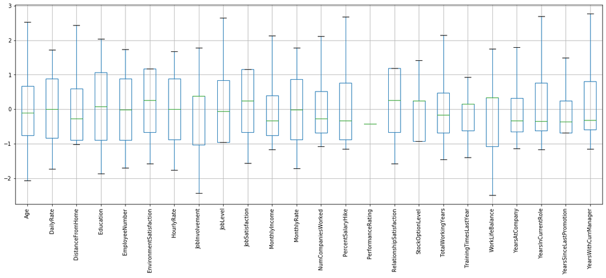

```python
plt.rcParams["figure.figsize"] = (20,7)
standard.boxplot(sym="")
plt.xticks(rotation=90)
```

```python
Attrition_map = {"Yes" : 1, "No": 0}
print(Attrition_map)
standard['Attrition']=standard['Attrition'].map(Attrition_map)
```

```
{'Yes': 1, 'No': 0}
```

### 2.3 Data Visualition

- what is the employee attririton rate?
- which kind of people leave the company the most?
- after how many years most people try to leave the company?
- what are the distrbution of numeric attributes?
- Exploring Age statistics?
- what is the relationshp between attrition and ( overTime, Monthly Income, Total Working years, Marital Statues)?

### Visualizing the value distribution for each numeric column in the dataset

```
array([[<matplotlib.axes._subplots.AxesSubplot object at 0x000001AAF3C99088>,
      dtype=object)
```

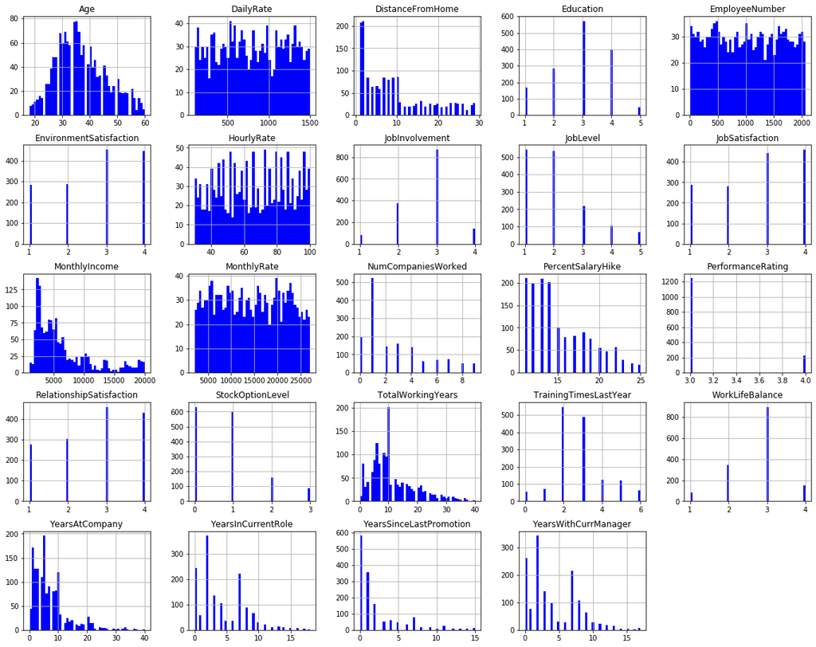

```python
df.hist(bins=50,figsize=(20,16), color= "blue")
```

### What is the attrition rate?

```python
lab = df["Attrition"].value_counts().keys().tolist()
#values
val = df["Attrition"].value_counts().values.tolist()
trace = go.Pie(labels=lab,
                values=val,
                marker=dict(colors=[  '#0000cc', "#ff0000"]),
                # Seting values to
                hoverinfo="value"
              )

layout = go.Layout(title="Employee Attration Distribution",
)
data = [trace]
fig = go.Figure(data = data,layout = layout)
iplot(fig)
```

[interactive chart not shown]

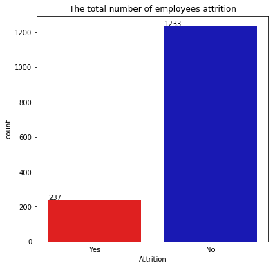

```python
colors = [  "#ff0000",  '#0000cc']
plt.rcParams["figure.figsize"] = (6,6)
ax = sns.countplot(x='Attrition', data=df, palette=colors)
plt.title("The total number of employees attrition")

for p in ax.patches:
    ax.annotate('{}'.format(p.get_height()), (p.get_x(), p.get_height()+1))
plt.show()
```

The previous percentages show that almost 84% of the employees included in the dataset did not suffer from attrition. Also, it can be observed that the data is imbalanced between the two class labels (83.8% for 'No' and 16.1% for 'Yes') of the 'Attrition' target column. Thus, there is a need to balance the sampling ratio during the training process of a classifier algorithm.

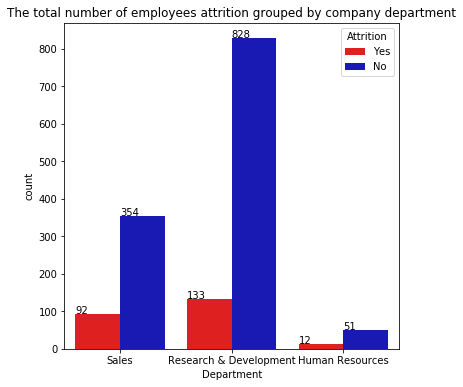

```python
colors = [  "#ff0000",  '#0000cc']
plt.rcParams["figure.figsize"] = (6,6)
ax = sns.countplot(x='Department', data=df, hue="Attrition", palette=colors)
plt.title("The total number of employees attrition grouped by company department")
for p in ax.patches:
    ax.annotate('{}'.format(p.get_height()), (p.get_x(), p.get_height()+1))
plt.show()
```

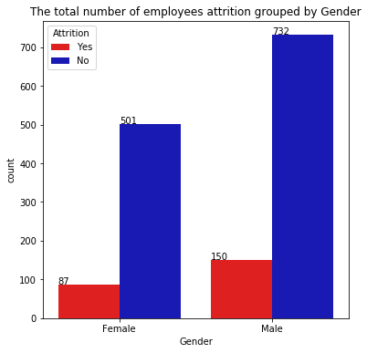

```python
colors = [  "#ff0000",  '#0000cc']
plt.rcParams["figure.figsize"] = (6,6)
ax = sns.countplot(x='Gender', data=df, hue="Attrition", palette=colors)
plt.title("The total number of employees attrition grouped by Gender")
for p in ax.patches:
    ax.annotate('{}'.format(p.get_height()), (p.get_x(), p.get_height()+1))
plt.show()
```

### - Visualizing the value distributions for each unique attrition value. The first figure is for Attrition='No', while the second figure is for Attrition='Yes'

```
Attrition
No     [[AxesSubplot(0.125,0.758226;0.125x0.121774), ...
Yes    [[AxesSubplot(0.125,0.758226;0.125x0.121774), ...
dtype: object
```

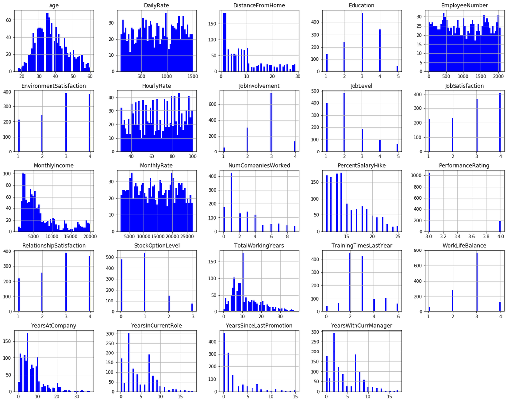

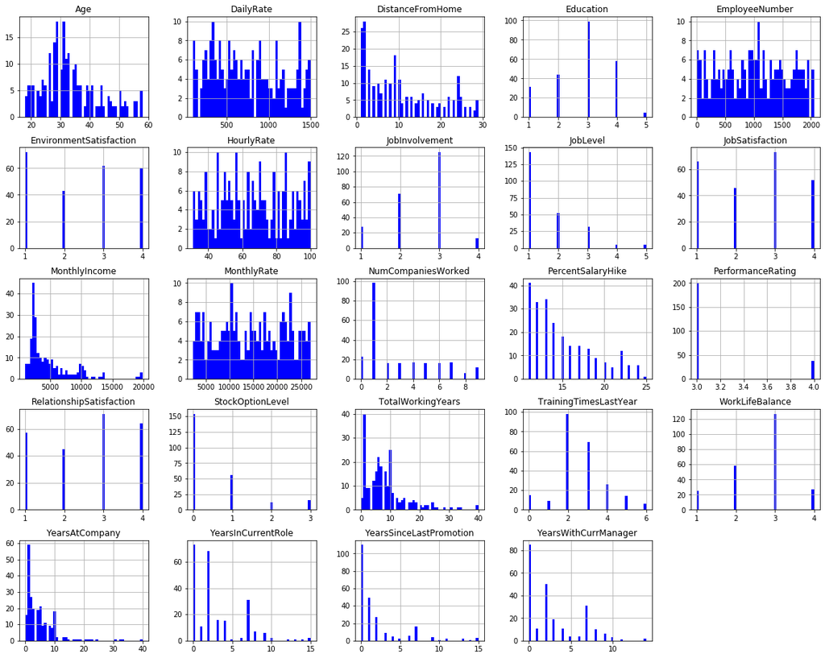

```python
df.groupby('Attrition').hist(bins=50,color= "blue",figsize=(20,16))
```

# Mapping the features

```python
Education_map = {1:"Below College", 2 :'College' ,3 : 'Bachelor' , 4 :'Master', 5 :'Doctor'}
df['Education'] = df['Education'].map(Education_map)
print("Education",Education_map)


EnvironmentSatisfaction_map = {1 :"Low", 2:"Medium", 3:"High", 4:"Very High"}
df["EnvironmentSatisfaction"] = df["EnvironmentSatisfaction"].map(EnvironmentSatisfaction_map)
print("EnvironmentSatisfaction",EnvironmentSatisfaction_map)


JobInvolvement_map = {1 :"Low", 2:"Medium", 3:"High", 4:"Very High"}
df["JobInvolvement"] = df["JobInvolvement"].map(JobInvolvement_map)
print("JobInvolvement", JobInvolvement_map)

JobSatisfaction_map = {1 :"Low", 2:"Medium", 3:"High", 4:"Very High"}
df["JobSatisfaction"] = df["JobSatisfaction"].map(JobSatisfaction_map)
print("JobSatisfaction", JobSatisfaction_map)

PerformanceRating_map = {1 :"Low", 2:"Medium", 3:"High", 4:"Outstanding"}
df["PerformanceRating"] = df["PerformanceRating"].map(PerformanceRating_map)
print("PerformanceRating", PerformanceRating_map)


RelationshipSatisfaction_map = {1 :"Low", 2:"Medium", 3:"High", 4:"Outstanding"}
df["RelationshipSatisfaction"] = df["RelationshipSatisfaction"].map(RelationshipSatisfaction_map)
print("RelationshipSatisfaction", RelationshipSatisfaction_map)

WorkLifeBalance_map = {1 :"Low", 2:"Medium", 3:"High", 4:"Outstanding"}
df["WorkLifeBalance"] = df["WorkLifeBalance"].map(WorkLifeBalance_map)
print("WorkLifeBalance", WorkLifeBalance_map)
```

```
Education {1: 'Below College', 2: 'College', 3: 'Bachelor', 4: 'Master', 5: 'Doctor'}
EnvironmentSatisfaction {1: 'Low', 2: 'Medium', 3: 'High', 4: 'Very High'}
JobInvolvement {1: 'Low', 2: 'Medium', 3: 'High', 4: 'Very High'}
JobSatisfaction {1: 'Low', 2: 'Medium', 3: 'High', 4: 'Very High'}
PerformanceRating {1: 'Low', 2: 'Medium', 3: 'High', 4: 'Outstanding'}
RelationshipSatisfaction {1: 'Low', 2: 'Medium', 3: 'High', 4: 'Outstanding'}
WorkLifeBalance {1: 'Low', 2: 'Medium', 3: 'High', 4: 'Outstanding'}
```

# Age

```python
youngest = df['Age'].min()
print(" The youngest employee was in his ", youngest)
```

```
 The youngest employee was in his  18
```

```python
oldest = df['Age'].max()
print(" The oldest employee  was in his ", oldest)
```

```
 The oldest employee  was in his  60
```

```python
df[df['Age']==oldest]
```

|  | Age | Attrition | BusinessTravel | DailyRate | Department | DistanceFromHome | Education | EducationField | EmployeeNumber | EnvironmentSatisfaction | ... | PerformanceRating | RelationshipSatisfaction | StockOptionLevel | TotalWorkingYears | TrainingTimesLastYear | WorkLifeBalance | YearsAtCompany | YearsInCurrentRole | YearsSinceLastPromotion | YearsWithCurrManager |
| --- | --- | --- | --- | --- | --- | --- | --- | --- | --- | --- | --- | --- | --- | --- | --- | --- | --- | --- | --- | --- | --- |
| 411 | 60 | No | Travel_Rarely | 422 | Research & Development | 7 | Bachelor | Life Sciences | 549 | Low | ... | High | Outstanding | 0 | 33 | 5 | Low | 29 | 8 | 11 | 10 |
| 427 | 60 | No | Travel_Frequently | 1499 | Sales | 28 | Bachelor | Marketing | 573 | High | ... | High | Outstanding | 0 | 22 | 5 | Outstanding | 18 | 13 | 13 | 11 |
| 536 | 60 | No | Travel_Rarely | 1179 | Sales | 16 | Master | Marketing | 732 | Low | ... | High | Outstanding | 0 | 10 | 1 | High | 2 | 2 | 2 | 2 |
| 879 | 60 | No | Travel_Rarely | 696 | Sales | 7 | Master | Marketing | 1233 | Medium | ... | High | Medium | 1 | 12 | 3 | High | 11 | 7 | 1 | 9 |
| 1209 | 60 | No | Travel_Rarely | 370 | Research & Development | 1 | Master | Medical | 1697 | High | ... | Outstanding | High | 1 | 19 | 2 | Outstanding | 1 | 0 | 0 | 0 |

5 rows × 32 columns

```python
df[df['Age']==youngest]
```

|  | Age | Attrition | BusinessTravel | DailyRate | Department | DistanceFromHome | Education | EducationField | EmployeeNumber | EnvironmentSatisfaction | ... | PerformanceRating | RelationshipSatisfaction | StockOptionLevel | TotalWorkingYears | TrainingTimesLastYear | WorkLifeBalance | YearsAtCompany | YearsInCurrentRole | YearsSinceLastPromotion | YearsWithCurrManager |
| --- | --- | --- | --- | --- | --- | --- | --- | --- | --- | --- | --- | --- | --- | --- | --- | --- | --- | --- | --- | --- | --- |
| 296 | 18 | Yes | Travel_Rarely | 230 | Research & Development | 3 | Bachelor | Life Sciences | 405 | High | ... | High | High | 0 | 0 | 2 | High | 0 | 0 | 0 | 0 |
| 301 | 18 | No | Travel_Rarely | 812 | Sales | 10 | Bachelor | Medical | 411 | Very High | ... | High | Low | 0 | 0 | 2 | High | 0 | 0 | 0 | 0 |
| 457 | 18 | Yes | Travel_Frequently | 1306 | Sales | 5 | Bachelor | Marketing | 614 | Medium | ... | High | Outstanding | 0 | 0 | 3 | High | 0 | 0 | 0 | 0 |
| 727 | 18 | No | Non-Travel | 287 | Research & Development | 5 | College | Life Sciences | 1012 | Medium | ... | High | Outstanding | 0 | 0 | 2 | High | 0 | 0 | 0 | 0 |
| 828 | 18 | Yes | Non-Travel | 247 | Research & Development | 8 | Below College | Medical | 1156 | High | ... | High | Outstanding | 0 | 0 | 0 | High | 0 | 0 | 0 | 0 |
| 972 | 18 | No | Non-Travel | 1124 | Research & Development | 1 | Bachelor | Life Sciences | 1368 | Very High | ... | High | High | 0 | 0 | 5 | Outstanding | 0 | 0 | 0 | 0 |
| 1153 | 18 | Yes | Travel_Frequently | 544 | Sales | 3 | College | Medical | 1624 | Medium | ... | High | High | 0 | 0 | 2 | Outstanding | 0 | 0 | 0 | 0 |
| 1311 | 18 | No | Non-Travel | 1431 | Research & Development | 14 | Bachelor | Medical | 1839 | Medium | ... | High | High | 0 | 0 | 4 | Low | 0 | 0 | 0 | 0 |

8 rows × 32 columns

```python
mean_age = df["Age"].mean()
print ( " The mean age is ", mean_age)
```

```
 The mean age is  36.923809523809524
```

```python
df["Age"].describe()
```

```
count    1470.000000
mean       36.923810
std         9.135373
min        18.000000
25%        30.000000
50%        36.000000
75%        43.000000
max        60.000000
Name: Age, dtype: float64
```

# 1.Relationship of Over Time Worked to Attrition

```python
lab = df["OverTime"].value_counts().keys().tolist()
#values
val = df["OverTime"].value_counts().values.tolist()
trace = go.Pie(labels=lab,
                values=val,
                marker=dict(colors=[  '#0000cc', "#ff0000"]),
                # Seting values to
                hoverinfo="value"
              )

layout = go.Layout(title="Overtime Worked to Attrition",
)
data = [trace]
fig = go.Figure(data = data,layout = layout)
iplot(fig)
```

[interactive chart not shown]

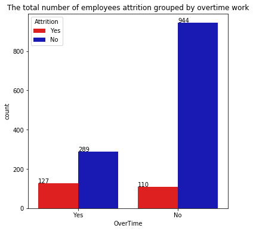

```python
colors = [  "#ff0000",  '#0000cc']
plt.rcParams["figure.figsize"] = (6,6)
ax = sns.countplot(x='OverTime', data=df, hue="Attrition", palette=colors)
plt.title("The total number of employees attrition grouped by overtime work")
for p in ax.patches:
    ax.annotate('{}'.format(p.get_height()), (p.get_x(), p.get_height()+1))
plt.show()
```

# 2. Relationship of Total Working Years to Attrition

```python
# defining data
trace = go.Histogram(x=df['TotalWorkingYears'],nbinsx=40,histnorm='percent')
data = [trace]

# defining layout
layout = go.Layout(title="Total Working Years Distribution")

# defining figure and plotting
fig = go.Figure(data = data,layout = layout)
iplot(fig)
```

[interactive chart not shown]

```python
 df["TotalWorkingYears"].describe()
```

```
count    1470.000000
mean       11.279592
std         7.780782
min         0.000000
25%         6.000000
50%        10.000000
75%        15.000000
max        40.000000
Name: TotalWorkingYears, dtype: float64
```

```python
 df.loc[df['TotalWorkingYears'] == 0]
```

|  | Age | Attrition | BusinessTravel | DailyRate | Department | DistanceFromHome | Education | EducationField | EmployeeNumber | EnvironmentSatisfaction | ... | PerformanceRating | RelationshipSatisfaction | StockOptionLevel | TotalWorkingYears | TrainingTimesLastYear | WorkLifeBalance | YearsAtCompany | YearsInCurrentRole | YearsSinceLastPromotion | YearsWithCurrManager |
| --- | --- | --- | --- | --- | --- | --- | --- | --- | --- | --- | --- | --- | --- | --- | --- | --- | --- | --- | --- | --- | --- |
| 23 | 21 | No | Travel_Rarely | 391 | Research & Development | 15 | College | Life Sciences | 30 | High | ... | High | Outstanding | 0 | 0 | 6 | High | 0 | 0 | 0 | 0 |
| 127 | 19 | Yes | Travel_Rarely | 528 | Sales | 22 | Below College | Marketing | 167 | Very High | ... | High | Outstanding | 0 | 0 | 2 | Medium | 0 | 0 | 0 | 0 |
| 296 | 18 | Yes | Travel_Rarely | 230 | Research & Development | 3 | Bachelor | Life Sciences | 405 | High | ... | High | High | 0 | 0 | 2 | High | 0 | 0 | 0 | 0 |
| 301 | 18 | No | Travel_Rarely | 812 | Sales | 10 | Bachelor | Medical | 411 | Very High | ... | High | Low | 0 | 0 | 2 | High | 0 | 0 | 0 | 0 |
| 457 | 18 | Yes | Travel_Frequently | 1306 | Sales | 5 | Bachelor | Marketing | 614 | Medium | ... | High | Outstanding | 0 | 0 | 3 | High | 0 | 0 | 0 | 0 |
| 615 | 27 | No | Non-Travel | 443 | Research & Development | 3 | Bachelor | Medical | 850 | Very High | ... | High | High | 3 | 0 | 6 | Medium | 0 | 0 | 0 | 0 |
| 727 | 18 | No | Non-Travel | 287 | Research & Development | 5 | College | Life Sciences | 1012 | Medium | ... | High | Outstanding | 0 | 0 | 2 | High | 0 | 0 | 0 | 0 |
| 828 | 18 | Yes | Non-Travel | 247 | Research & Development | 8 | Below College | Medical | 1156 | High | ... | High | Outstanding | 0 | 0 | 0 | High | 0 | 0 | 0 | 0 |
| 972 | 18 | No | Non-Travel | 1124 | Research & Development | 1 | Bachelor | Life Sciences | 1368 | Very High | ... | High | High | 0 | 0 | 5 | Outstanding | 0 | 0 | 0 | 0 |
| 1153 | 18 | Yes | Travel_Frequently | 544 | Sales | 3 | College | Medical | 1624 | Medium | ... | High | High | 0 | 0 | 2 | Outstanding | 0 | 0 | 0 | 0 |
| 1311 | 18 | No | Non-Travel | 1431 | Research & Development | 14 | Bachelor | Medical | 1839 | Medium | ... | High | High | 0 | 0 | 4 | Low | 0 | 0 | 0 | 0 |

11 rows × 32 columns

```python
 df.loc[df['TotalWorkingYears'] == 40]
```

|  | Age | Attrition | BusinessTravel | DailyRate | Department | DistanceFromHome | Education | EducationField | EmployeeNumber | EnvironmentSatisfaction | ... | PerformanceRating | RelationshipSatisfaction | StockOptionLevel | TotalWorkingYears | TrainingTimesLastYear | WorkLifeBalance | YearsAtCompany | YearsInCurrentRole | YearsSinceLastPromotion | YearsWithCurrManager |
| --- | --- | --- | --- | --- | --- | --- | --- | --- | --- | --- | --- | --- | --- | --- | --- | --- | --- | --- | --- | --- | --- |
| 126 | 58 | Yes | Travel_Rarely | 147 | Research & Development | 23 | Master | Medical | 165 | Very High | ... | High | Outstanding | 1 | 40 | 3 | Medium | 40 | 10 | 15 | 6 |
| 595 | 58 | Yes | Travel_Rarely | 286 | Research & Development | 2 | Master | Life Sciences | 825 | Very High | ... | High | Outstanding | 0 | 40 | 2 | High | 31 | 15 | 13 | 8 |

2 rows × 32 columns

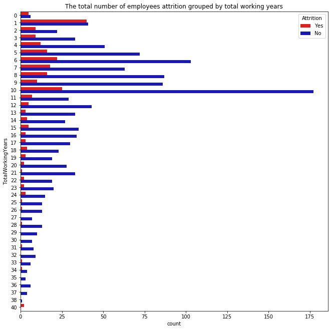

```python
colors = [  "#ff0000",  '#0000cc']
plt.rcParams["figure.figsize"] = (11,11)
plt.title("The total number of employees attrition grouped by total working years")
sns.countplot(y="TotalWorkingYears" , data= df ,hue= "Attrition", palette= colors)
```

From the graphs above we can see probability of attrition is highest for lower total working years.

# 3. Relationship of Monthly Income to Attrition

```python
df["MonthlyIncome"].describe()
```

```
count     1470.000000
mean      6502.931293
std       4707.956783
min       1009.000000
25%       2911.000000
50%       4919.000000
75%       8379.000000
max      19999.000000
Name: MonthlyIncome, dtype: float64
```

```python
min = df["MonthlyIncome"].min()
print ("The minimum monthly income is", min)
df[df["MonthlyIncome"]==min]
```

```
The minimum monthly income is 1009
```

|  | Age | Attrition | BusinessTravel | DailyRate | Department | DistanceFromHome | Education | EducationField | EmployeeNumber | EnvironmentSatisfaction | ... | PerformanceRating | RelationshipSatisfaction | StockOptionLevel | TotalWorkingYears | TrainingTimesLastYear | WorkLifeBalance | YearsAtCompany | YearsInCurrentRole | YearsSinceLastPromotion | YearsWithCurrManager |
| --- | --- | --- | --- | --- | --- | --- | --- | --- | --- | --- | --- | --- | --- | --- | --- | --- | --- | --- | --- | --- | --- |
| 513 | 20 | Yes | Travel_Rarely | 1362 | Research & Development | 10 | Below College | Medical | 701 | Very High | ... | High | Outstanding | 0 | 1 | 5 | High | 1 | 0 | 1 | 1 |

1 rows × 32 columns

```python
max = df["MonthlyIncome"].max()
print ("The maximum monthly income is", max)
df[df["MonthlyIncome"]==max]
```

```
The maximum monthly income is 19999
```

|  | Age | Attrition | BusinessTravel | DailyRate | Department | DistanceFromHome | Education | EducationField | EmployeeNumber | EnvironmentSatisfaction | ... | PerformanceRating | RelationshipSatisfaction | StockOptionLevel | TotalWorkingYears | TrainingTimesLastYear | WorkLifeBalance | YearsAtCompany | YearsInCurrentRole | YearsSinceLastPromotion | YearsWithCurrManager |
| --- | --- | --- | --- | --- | --- | --- | --- | --- | --- | --- | --- | --- | --- | --- | --- | --- | --- | --- | --- | --- | --- |
| 190 | 52 | No | Travel_Rarely | 699 | Research & Development | 1 | Master | Life Sciences | 259 | High | ... | High | Low | 1 | 34 | 5 | High | 33 | 18 | 11 | 9 |

1 rows × 32 columns

```python
# defining data
trace = go.Histogram(x=df['MonthlyIncome'],nbinsx=40,histnorm='percent')
data = [trace]

# defining layout
layout = go.Layout(title="Monthly Income Distribution")

# defining figure and plotting
fig = go.Figure(data = data,layout = layout)
iplot(fig)

print("Do the same as above")
```

[interactive chart not shown]

```
Do the same as above
```

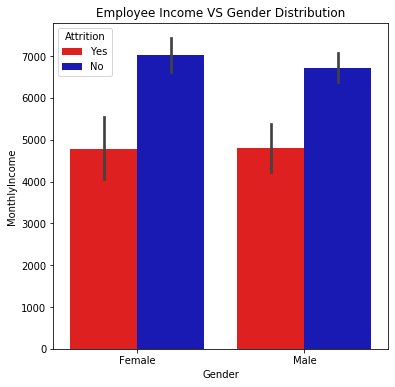

```python
colors = [  "#ff0000",  '#0000cc']
plt.rcParams["figure.figsize"] = (6,6)
sns.barplot(x='Gender',y='MonthlyIncome',hue='Attrition',  palette=colors,data=df).set_title('Employee Income VS Gender Distribution')
plt.figure(figsize=(10, 10))
plt.show()
```

# 4. Relationship of Marital Status to Attrition

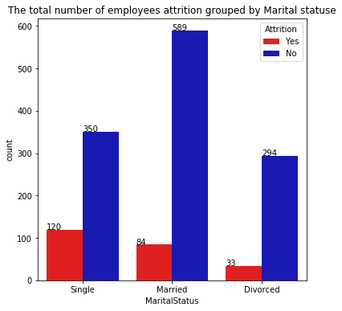

```python
colors = [  "#ff0000",  '#0000cc']
plt.rcParams["figure.figsize"] = (6,6)
ax = sns.countplot(x='MaritalStatus', data=df, hue="Attrition", palette=colors)
plt.title("The total number of employees attrition grouped by Marital statuse")
for p in ax.patches:
    ax.annotate('{}'.format(p.get_height()), (p.get_x(), p.get_height()+1))
plt.show()
```

```python
lab = df["MaritalStatus"].value_counts().keys().tolist()
#values
val = df["MaritalStatus"].value_counts().values.tolist()
trace = go.Pie(labels=lab,
                values=val,
                marker=dict(colors=[  '#0000cc',"#ffcccc", "#ff0000"]),
                # Seting values to
                hoverinfo="value"
              )

layout = go.Layout(title="Marital Status Distrbution",
)
data = [trace]
fig = go.Figure(data = data,layout = layout)
iplot(fig)
```

[interactive chart not shown]

Most attrition is in the Single category in terms on proportion of people who leave. But in terms of overall numbers, the highest attrition is also from Single category

# Correlation

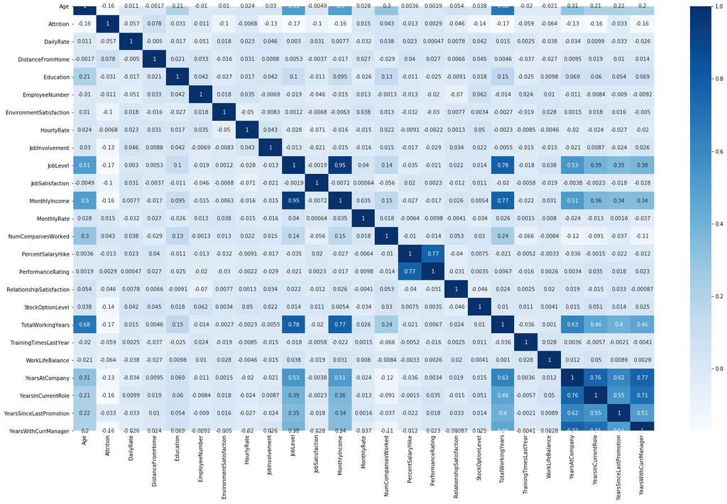

```python
data_correlation = standard.corr()
plt.rcParams["figure.figsize"] = [25,15]
sns.heatmap(data_correlation,xticklabels=data_correlation.columns,yticklabels=data_correlation.columns,annot=True,cmap="Blues")
```

# Hourly rate

### Are employees leaving because they are poorly paid?

```
 The Avrage of Hourly rate is  20.704225352112676
The Standerd Diviation of Hourly rate is  4.146589863793162
```

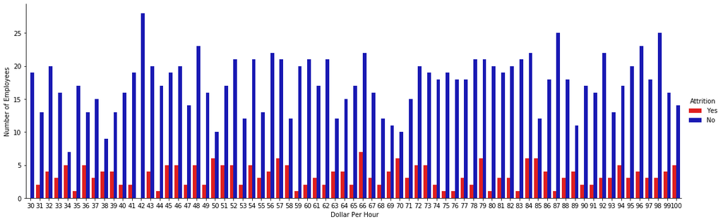

```python
print(" The Avrage of Hourly rate is ", df.HourlyRate.value_counts().mean())
print("The Standerd Diviation of Hourly rate is ", np.std(df.HourlyRate.value_counts()))
colors = [  "#ff0000",  '#0000cc']
sns.axes_style('whitegrid')
sns.catplot('HourlyRate', data=df, aspect=3, kind='count', hue='Attrition', palette=colors).set_ylabels('Number of Employees')
plt.xlabel(" Dollar Per Hour")
```